# Advanced motif and sequence manipulation

Benjamin Tremblay

University of Waterloo, Waterloo, Canada

b2tremblay@uwaterloo.ca

18 août 2018

#### Abstract

Introducing sequence motif types.

# Contents

## 0.1 Multi-letter information

Though PCM/PPM/PWM/ICM type motifs are still widely used today, a few ‘next generation’ motif formats have been proposed. These wish to add another layer of information to motifs: nucleotide interdependence. To illustrate this, consider the following sequences:

Table 1: Example sequences

| # | Sequence |
| --- | --- |
| 1 | CAAAACC |
| 2 | CAAAACC |
| 3 | CAAAACC |
| 4 | CTTTTCC |
| 5 | CTTTTCC |
| 6 | CTTTTCC |

This becomes the following PPM:

Table 2: Position probability matrix

| Position | 1 | 2 | 3 | 4 | 5 | 6 | 7 |
| --- | --- | --- | --- | --- | --- | --- | --- |
| A | 0.0 | 0.5 | 0.5 | 0.5 | 0.5 | 0.0 | 0.0 |
| C | 1.0 | 0.0 | 0.0 | 0.0 | 0.0 | 1.0 | 1.0 |
| G | 0.0 | 0.0 | 0.0 | 0.0 | 0.0 | 0.0 | 0.0 |
| T | 0.0 | 0.5 | 0.5 | 0.5 | 0.5 | 0.0 | 0.0 |

Based on the PPM representation, all three of CAAAACC, CTTTTCC, and CTATACC are equally likely. Though looking at the starting sequences, should CTATACC really be considered so? For transcription factor binding sites, generally the answer is no. By incorporating this type of information into the motif, this can allow for increased accuracy in motif searching. A few implementations of this include: TFFM by Mathelier and Wasserman (2013), BaMM by Siebert and Soding (2016), and KSM by Guo et al. (2018).

The *universalmotif* package implements its’ own, much simplified, version of this concept. Plainly, the standard PPM has been extended to include k-letter frequencies, with k being any number higher than 1. For example, the 2-letter version of the table 2 motif would be:

Table 3: 2-letter probability matrix

| Position | 1 | 2 | 3 | 4 | 5 | 6 |
| --- | --- | --- | --- | --- | --- | --- |
| AA | 0.0 | 0.5 | 0.5 | 0.5 | 0.0 | 0.0 |
| AC | 0.0 | 0.0 | 0.0 | 0.0 | 0.5 | 0.0 |
| AG | 0.0 | 0.0 | 0.0 | 0.0 | 0.0 | 0.0 |
| AT | 0.0 | 0.0 | 0.0 | 0.0 | 0.0 | 0.0 |
| CA | 0.5 | 0.0 | 0.0 | 0.0 | 0.0 | 0.0 |
| CC | 0.0 | 0.0 | 0.0 | 0.0 | 0.0 | 1.0 |
| CG | 0.0 | 0.0 | 0.0 | 0.0 | 0.0 | 0.0 |
| CT | 0.5 | 0.0 | 0.0 | 0.0 | 0.0 | 0.0 |
| GA | 0.0 | 0.0 | 0.0 | 0.0 | 0.0 | 0.0 |
| GC | 0.0 | 0.0 | 0.0 | 0.0 | 0.0 | 0.0 |
| GG | 0.0 | 0.0 | 0.0 | 0.0 | 0.0 | 0.0 |
| GT | 0.0 | 0.0 | 0.0 | 0.0 | 0.0 | 0.0 |
| TA | 0.0 | 0.0 | 0.0 | 0.0 | 0.0 | 0.0 |
| TC | 0.0 | 0.0 | 0.0 | 0.0 | 0.5 | 0.0 |
| TG | 0.0 | 0.0 | 0.0 | 0.0 | 0.0 | 0.0 |
| TT | 0.0 | 0.5 | 0.5 | 0.5 | 0.0 | 0.0 |

This format shows the probability of each letter combined with the probability of the letter in the next position. The seventh column has been dropped, since it is not needed; the information in the sixth column is sufficient, and there is no eighth position to draw 2-letter probabilities from. Now, the probability of getting CTATACC is no longer equal to CTTTTCC and CAAAACC. This information is kept in the `multifreq` slot of `universalmotif` class motifs. To add this information, use the `add_multifreq` function.

```r
library(universalmotif)
library(Biostrings)

motif <- create_motif("CWWWWCC", nsites = 6)  ## -> see next section
sequences <- DNAStringSet(rep(c("CAAAACC", "CTTTTCC"), 3))
motif.k2 <- add_multifreq(motif, sequences, add.k = 2)
motif.k2
```

```
#>
#>        Motif name:   motif
#>          Alphabet:   DNA
#>              Type:   PPM
#>           Strands:   +-
#>          Total IC:   10
#>         Consensus:   CWWWWCC
#>      Target sites:   6
#>    k-letter freqs:   2
#>
#>   C   W   W   W   W C C
#> A 0 0.5 0.5 0.5 0.5 0 0
#> C 1 0.0 0.0 0.0 0.0 1 1
#> G 0 0.0 0.0 0.0 0.0 0 0
#> T 0 0.5 0.5 0.5 0.5 0 0
```

## 0.2 Motif trees with ggtree and motifStack

The *motifStack* offers a number of excellent functions for comparing motifs. Any of them can be used after using `convert_motifs`. Additionally, this package introduces the `motif_tree` function for generating basic tree-like diagrams for comparing motifs.

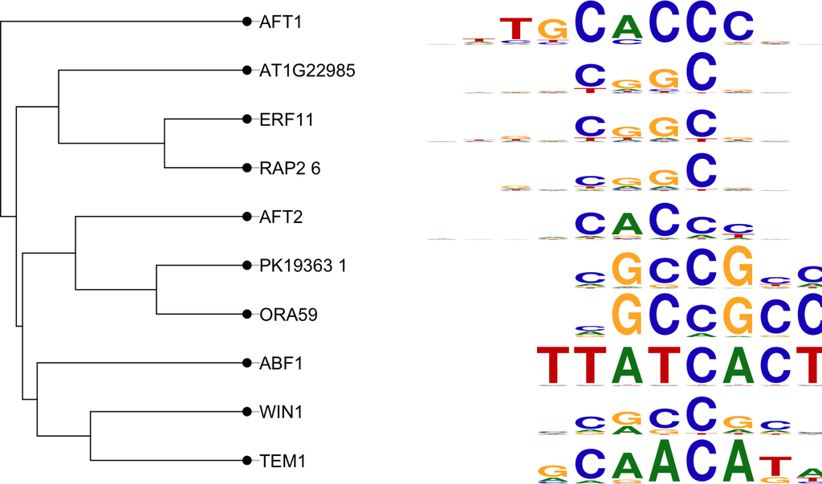

```r
library(universalmotif)
library(MotifDb)

## A simple motifStack example:
motifs <- convert_motifs(MotifDb[1:10], "motifStack-pfm")
motifStack::motifStack(motifs, layout = "phylog")
```

```r
## motif_tree is much simpler, but also much faster and allows for
## bigger trees; done via the ggtree package
motif_tree(MotifDb[301:400], layout = "daylight", linecol = "family")
```

```
#> Average angle change [1] 0.080931235825627
#> Average angle change [2] 0.02439105682278
```

[figure not shown]

# References

Guo, Y., K. Tian, H. Zeng, X. Guo, and D.K. Gifford. 2018. “A Novel K-Mer Set Memory (KSM) Motif Representation Improves Regulatory Variant Prediction.” *Genome Research* 28: 891–900.

Mathelier, A., and W.W. Wasserman. 2013. “The Next Generation of Transcription Factor Binding Site Prediction.” *PLoS Computational Biology* 9 (9): e1003214.

Siebert, M., and J. Soding. 2016. “Bayesian Markov Models Consistently Outperform PWMs at Predicting Motifs in Nucleotide Sequences.” *Nucleic Acids Research* 44 (13): 6055–69.